# Rural India Financial Analysis

Asad Ahamad

February 18, 2018

- Introduction
- Libraries
- Import Data
- Data Cleaning
- Exploratory Data Analysis
- Data Modeling

## Introduction

In Banking industry, loan applications are generally approved after a thorough background check of the customer’s repayment capabilities. Credit Score plays a significant role in identifying customer’s financial behavior (specifically default). However, people belonging to rural India don’t have credit score and it is difficult to do a direct assessment.

We need to understand the maximum repayment capability of customers which can be used to grant them the desired amount.

## Libraries

```r
library(plyr)
library(dplyr)
library(ggplot2)
library(Hmisc)
library(readxl)
library(mice)
library(VIM)
library(dummies)
library(caret)
theme_set(theme_bw())
```

## Import Data

Let’s read the data file provided for this:

```r
raw_data <- read.csv('Data/trainingData.csv',na.strings = c('NA', 'NULL', '#N/A', '#NAME?', '', 'nil', 'Nil'), stringsAsFactors = F)
```

Let’s check the quick summary and structure of data loaded

```r
describe(raw_data)
```

```
## raw_data
##
##  21  Variables      40000  Observations
## ---------------------------------------------------------------------------
## Id
##        n  missing distinct     Info     Mean      Gmd      .05      .10
##    40000        0    40000        1    20001    13334     2001     4001
##      .25      .50      .75      .90      .95
##    10001    20001    30000    36000    38000
##
## lowest :     1     2     3     4     5, highest: 39996 39997 39998 39999 40000
## ---------------------------------------------------------------------------
## city
##        n  missing distinct
##    38117     1883      854
##
## lowest : (KODANGAL MANDAL) NARVA 24 PARGANAS,SOUTH       752102                  AINTHAPALI              Ajidhya
## highest: Yeemiganur              Yellappa Garden         Yellapura               yemmiganur              Yemmiganur
## ---------------------------------------------------------------------------
## age
##        n  missing distinct     Info     Mean      Gmd      .05      .10
##    40000        0       62    0.999    55.16    48.49       22       25
##      .25      .50      .75      .90      .95
##       29       35       42       48       51
##
## Value           0 766000
## Frequency   39999      1
## Proportion      1      0
## ---------------------------------------------------------------------------
## sex
##        n  missing distinct
##    40000        0        3
##
## Value          F     M    TG
## Frequency  37622  2371     7
## Proportion 0.941 0.059 0.000
## ---------------------------------------------------------------------------
## social_class
##        n  missing distinct
##    34743     5257      518
```

[output cut: 132 more lines]

```
##    40000        0       21    0.604    21.76    14.76       12       12
##      .25      .50      .75      .90      .95
##       12       12       50       50       50
##
## lowest :  0  1  2  4  6, highest: 58 60 72 74 84
## ---------------------------------------------------------------------------
## loan_amount
##        n  missing distinct     Info     Mean      Gmd      .05      .10
##    40000        0      115    0.956     8413     3951     5000     5000
##      .25      .50      .75      .90      .95
##     5000     8000    10000    12000    15000
##
## lowest :     100     200     500    1000    1300
## highest:  500000  540000  563000 1000000 1343000
## ---------------------------------------------------------------------------
```

This shows there are missing values in data. There is very high values in columns age, annual_income, monthly_expense, occupants_count, house_area, and loan_amount.

Let’s check how many values are there after 99th percentile in each column:

```r
check_cols <- c('age', 'annual_income', 'monthly_expense', 'occupants_count', 'house_area', 'loan_amount')
for (i in 1:ncol(raw_data)){
  col_name = colnames(raw_data)[i]
  if(any(col_name %in% check_cols)){
    cat(paste('column no', i, 'with name', col_name , 'has '))
  cat(paste(sum(raw_data[,i] > quantile(raw_data[,i], probs = .99)), 'values.\n'))
  }
}
```

```
## column no 3 with name age has 345 values.
## column no 8 with name annual_income has 393 values.
## column no 14 with name occupants_count has 272 values.
## column no 15 with name house_area has 388 values.
## column no 21 with name loan_amount has 211 values.
```

Also check the missing value percentage in each column:

```r
for (i in 1:ncol(raw_data)){
  col_name = colnames(raw_data)[i]
  cat(paste('column no', i, 'with name', col_name , 'has '))
  cat(paste(sum(is.na(raw_data[, i]))/nrow(raw_data)*100, 'percent missing values.\n'))
}
```

```
## column no 1 with name Id has 0 percent missing values.
## column no 2 with name city has 4.7075 percent missing values.
## column no 3 with name age has 0 percent missing values.
## column no 4 with name sex has 0 percent missing values.
## column no 5 with name social_class has 13.1425 percent missing values.
## column no 6 with name primary_business has 0.065 percent missing values.
## column no 7 with name secondary_business has 13.1025 percent missing values.
## column no 8 with name annual_income has 0 percent missing values.
## column no 9 with name monthly_expenses has 0.3 percent missing values.
## column no 10 with name old_dependents has 0 percent missing values.
## column no 11 with name young_dependents has 0 percent missing values.
## column no 12 with name home_ownership has 0.9475 percent missing values.
## column no 13 with name type_of_house has 1.735 percent missing values.
## column no 14 with name occupants_count has 0 percent missing values.
## column no 15 with name house_area has 0 percent missing values.
## column no 16 with name sanitary_availability has 0.52 percent missing values.
## column no 17 with name water_availabity has 13.1325 percent missing values.
## column no 18 with name loan_purpose has 0.065 percent missing values.
## column no 19 with name loan_tenure has 0 percent missing values.
## column no 20 with name loan_installments has 0 percent missing values.
## column no 21 with name loan_amount has 0 percent missing values.
```

## Data Cleaning

Looking at the summary of each variable we notice that there are missing values and very high values in some columns. Before proceeding for exploaratory data analysis let’s clean the data:

### Missing values analysis

Let’s see what is the missing value distribution in data before imputing/correcting values

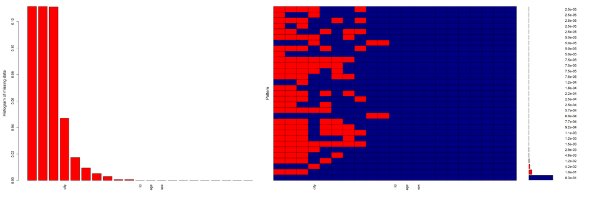

```
##
##  Variables sorted by number of missings:
##               Variable    Count
##           social_class 0.131425
##       water_availabity 0.131325
##     secondary_business 0.131025
##                   city 0.047075
##          type_of_house 0.017350
##         home_ownership 0.009475
##  sanitary_availability 0.005200
##       monthly_expenses 0.003000
##       primary_business 0.000650
##           loan_purpose 0.000650
##                     Id 0.000000
##                    age 0.000000
##                    sex 0.000000
##          annual_income 0.000000
##         old_dependents 0.000000
##       young_dependents 0.000000
##        occupants_count 0.000000
##             house_area 0.000000
##            loan_tenure 0.000000
##      loan_installments 0.000000
##            loan_amount 0.000000
```

```r
aggr_plot <- aggr(raw_data, col=c('navyblue','red'), numbers=TRUE, sortVars=TRUE, labels=names(raw_data), cex.axis=1, gap=3, ylab=c("Histogram of missing data","Pattern"))
```

Let’s replace missing values using predictive mean matching algorithm

```r
proc_data = mice(raw_data, m = 5, method = 'pmm', seed = 100)
proc_data <- complete(proc_data, 1)
```

### City

```r
proc_data$city <- tolower(proc_data$city)
proc_data$city[is.na(proc_data$city)] <- 'unknown'
```

### Age

As age has values more than 100 years we will clip the age to 100 and check its distribution

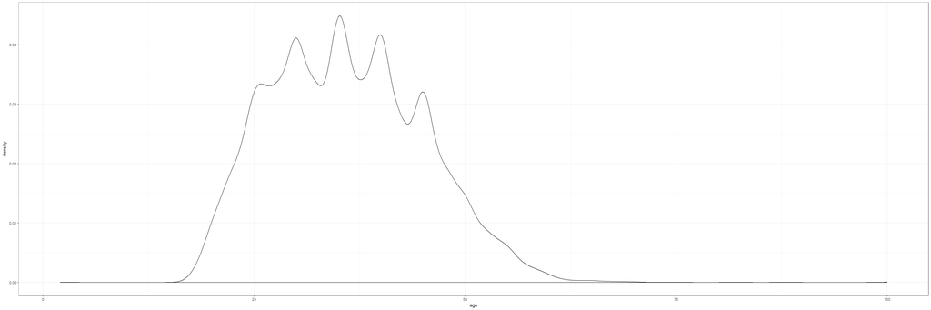

```r
proc_data$age[proc_data$age > 100] <- 100
ggplot(proc_data, aes(x = age)) + geom_density()
```

### Sex

There are three levels in Sex (M, F, TG) as there are very few TG applicant we can replace them with majority class

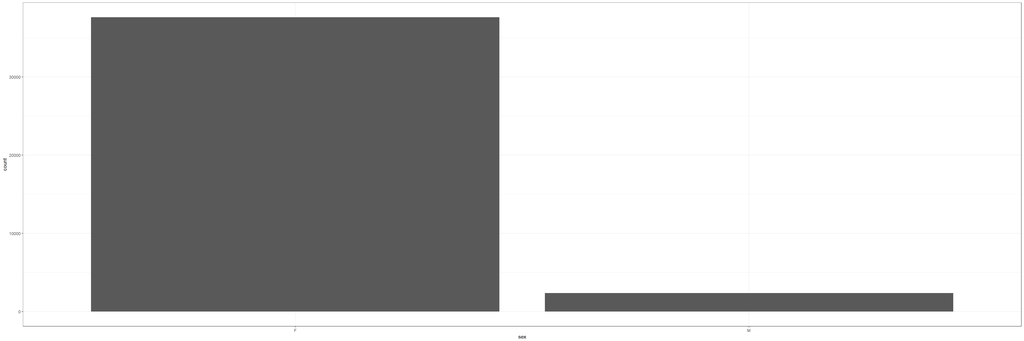

```r
proc_data$sex[proc_data$sex == 'TG'] <- 'F'
ggplot(proc_data, aes(x = sex)) + geom_bar()
```

### Social Class

```r
proc_data$social_class <- tolower(proc_data$social_class)
proc_data$social_class[is.na(proc_data$social_class)] <- 'unknown'
```

### Primary Business

Primary business has 441 distinct values

```r
proc_data$primary_business <- tolower(proc_data$primary_business)
proc_data$primary_business[is.na(proc_data$primary_business)] <- 'unknown'
```

### Secondary Business

```r
proc_data$secondary_business <- tolower(proc_data$secondary_business)
proc_data$secondary_business[is.na(proc_data$secondary_business)] <- 'unknown'
```

This column can be populated based on the values reported in primary_business column.

### Annual Income

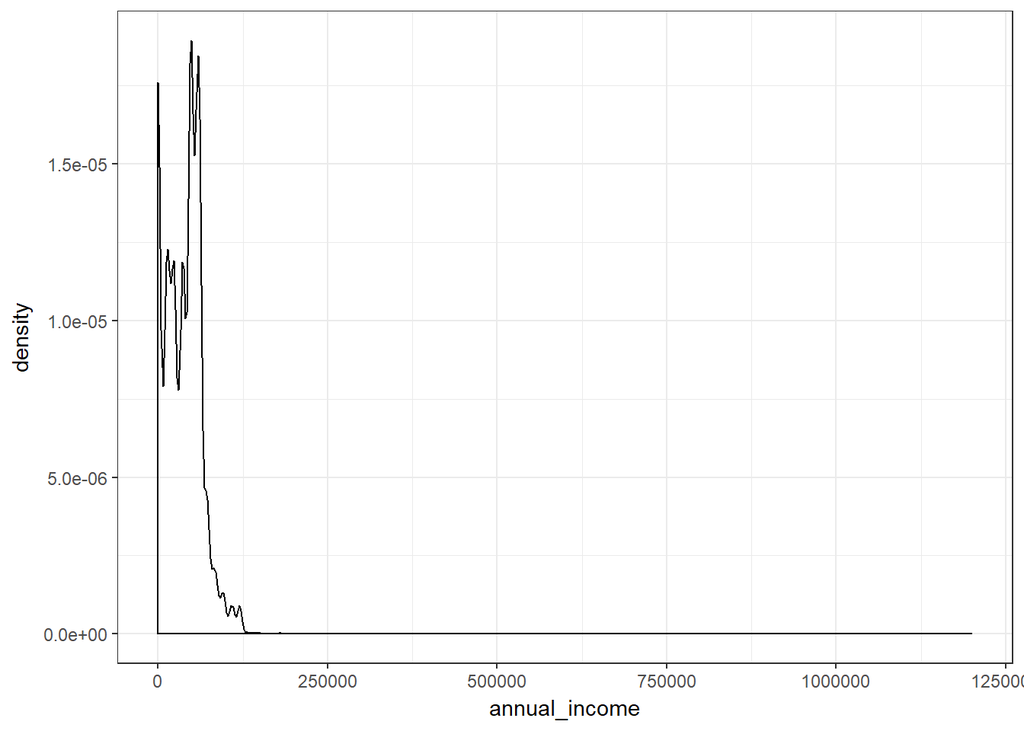

```r
ggplot(proc_data, aes(x = annual_income)) + geom_density()
```

It is clear after looking at this plot that there are few very high values. Let’s clip this column to 99th percentile

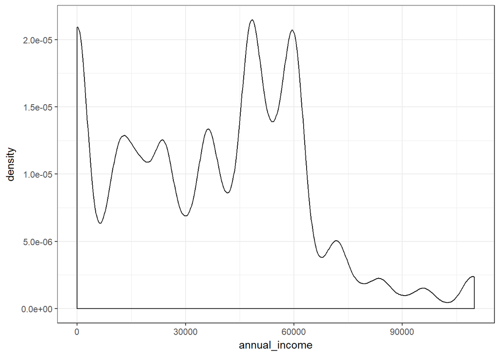

```r
perc_99 <- quantile(proc_data$annual_income, .99)
proc_data$annual_income[proc_data$annual_income > perc_99] <- perc_99
ggplot(proc_data, aes(x = annual_income)) + geom_density()
```

### Monthly Expense

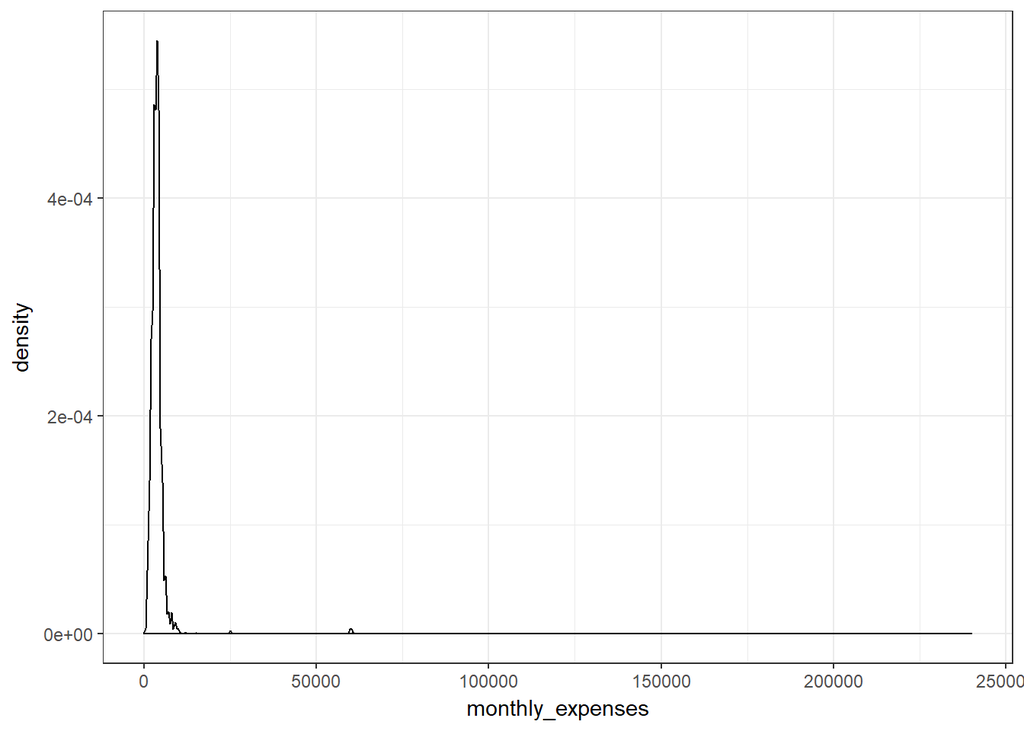

```r
ggplot(proc_data, aes(x = monthly_expenses)) + geom_density()
```

Same observation as annual_income, very few high values. We will do same treatment here

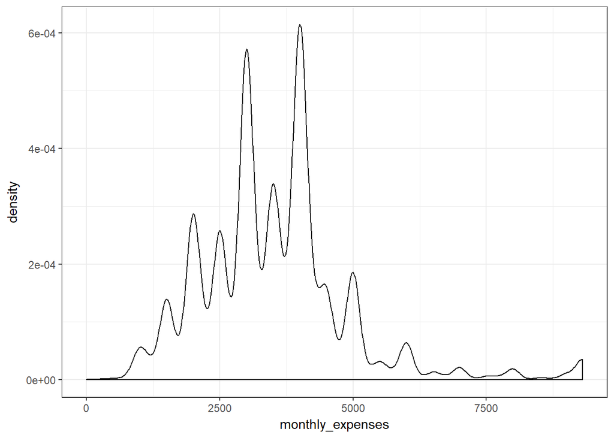

```r
perc_99 <- quantile(proc_data$monthly_expenses, .99)
proc_data$monthly_expenses[proc_data$monthly_expenses > perc_99] <- perc_99
ggplot(proc_data, aes(x = monthly_expenses)) + geom_density()
```

### Home Ownership

It is a flag varibale. We will replace missing values with majority class

```r
proc_data$home_ownership[is.na(proc_data$home_ownership)] <- 1
```

### House Type

Let’s replace missing values with majority class

```r
proc_data$type_of_house[is.na(proc_data$type_of_house)] <- 'T2'
```

### Occupants Count

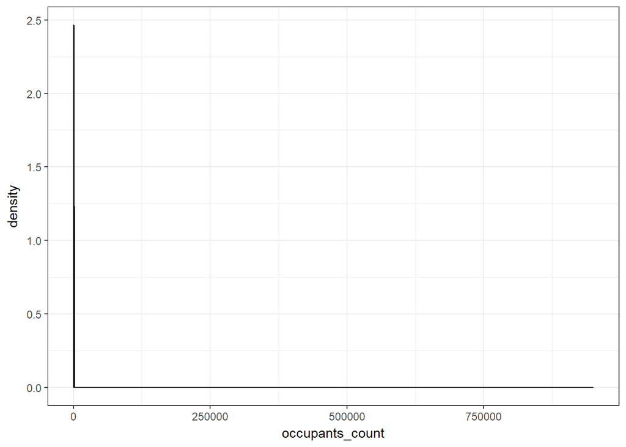

```r
ggplot(proc_data, aes(x = occupants_count)) + geom_density()
```

It has very high values, let’s clip it using 99th percentile value

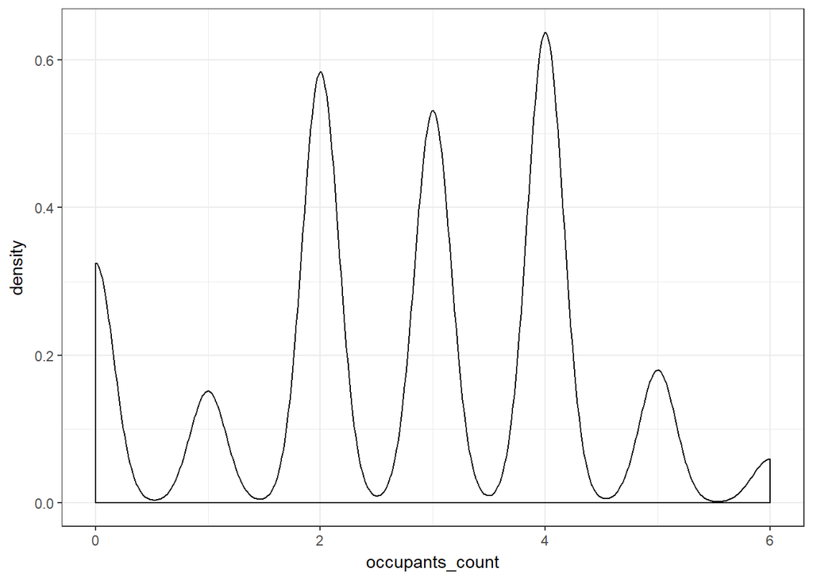

```r
perc_99 <- quantile(proc_data$occupants_count, .99)
proc_data$occupants_count[proc_data$occupants_count > perc_99] <- perc_99
ggplot(proc_data, aes(x = occupants_count)) + geom_density()
```

### House Area

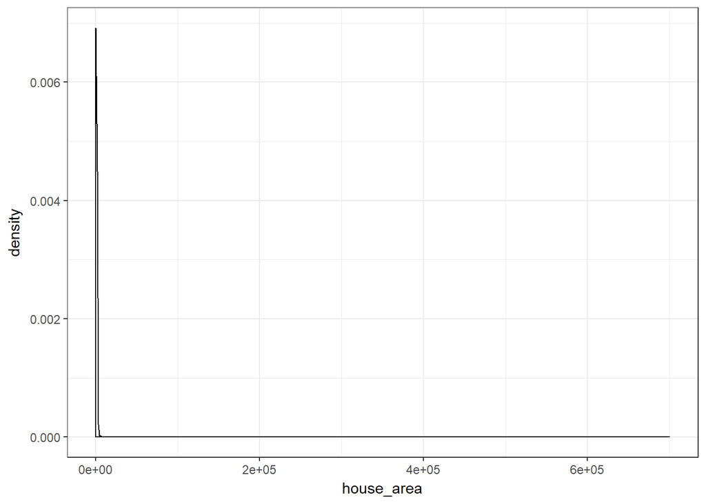

```r
ggplot(proc_data, aes(x = house_area)) + geom_density()
```

It has very high values, let’s clip it using 99th percentile value

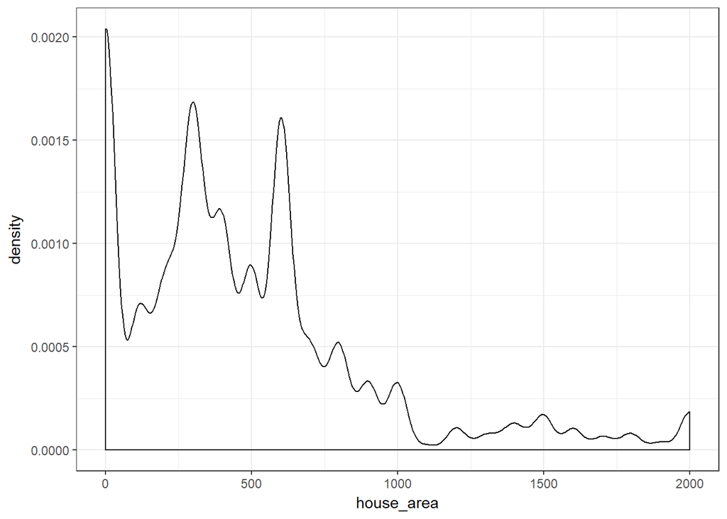

```r
perc_99 <- quantile(proc_data$house_area, .99)
proc_data$house_area[proc_data$house_area > perc_99] <- perc_99
ggplot(proc_data, aes(x = house_area)) + geom_density()
```

### Sanitary Availability

There is values -1 which is appeared once in data, we will replace it with next nearest value 0

```r
proc_data$sanitary_availability[proc_data$sanitary_availability == -1] <- 0
```

### Water Availability

There is values -1 which is appeared once in data, we will replace it with next nearest value 0

```r
proc_data$water_availabity[proc_data$water_availabity == -1] <- 0
```

### loan_purpose

There is 37 distinct values with 26 missig data points. As this variable is recommended by business we will try to fix it here so that it is usable in model

```r
proc_data$loan_purpose <- tolower(proc_data$loan_purpose)
proc_data$loan_purpose[is.na(proc_data$loan_purpose)] <- 'unknown'
proc_data$loan_purpose[proc_data$loan_purpose == 'cyber caf_'] <- 'cyber cafe'
```

## Exploratory Data Analysis

In exploraotry data analysis we will check how columns are associated with loan amount. Accordingly we can select/add features for loan amount prediction model.

### City

Let’s check the distribution of loan_amount in top 10 cities

```r
top_10_city = proc_data %>% group_by(city) %>% summarise(count = n(), mean_laon_amt = mean(loan_amount), sd_loan_amt = sd(loan_amount)) %>% arrange(count, desc(count)) %>% top_n(10, count)
knitr::kable(top_10_city, digits = 2, align = 'c', caption = 'Top 10 Cities')
```

Top 10 Cities

| city | count | mean_laon_amt | sd_loan_amt |
| --- | --- | --- | --- |
| pune | 978 | 8083.84 | 2726.00 |
| joynagar | 993 | 7744.21 | 2835.37 |
| sandeshkhali | 1183 | 6682.16 | 1895.42 |
| mathurapur | 1361 | 8855.25 | 3546.17 |
| gwalior | 1587 | 8633.14 | 2546.56 |
| imphal | 1702 | 9027.03 | 2558.98 |
| shantipur | 1727 | 11613.78 | 2513.39 |
| unknown | 1883 | 10627.08 | 38354.81 |
| bahoriband | 1979 | 8847.40 | 2177.87 |
| pusad | 4944 | 8877.79 | 3094.41 |

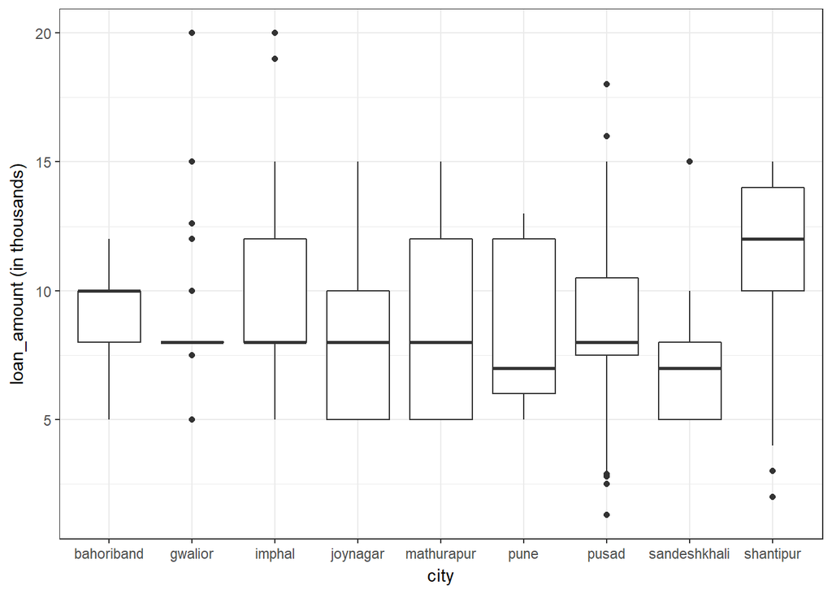

```r
top_10_city = top_10_city$city[top_10_city$city != 'unknown']
top_10_city_data <- proc_data %>% filter(city %in% top_10_city)
ggplot(top_10_city_data, aes(x = city, y = loan_amount/1000)) + geom_boxplot() +
 ylab('loan_amount (in thousands)')
```

### Age

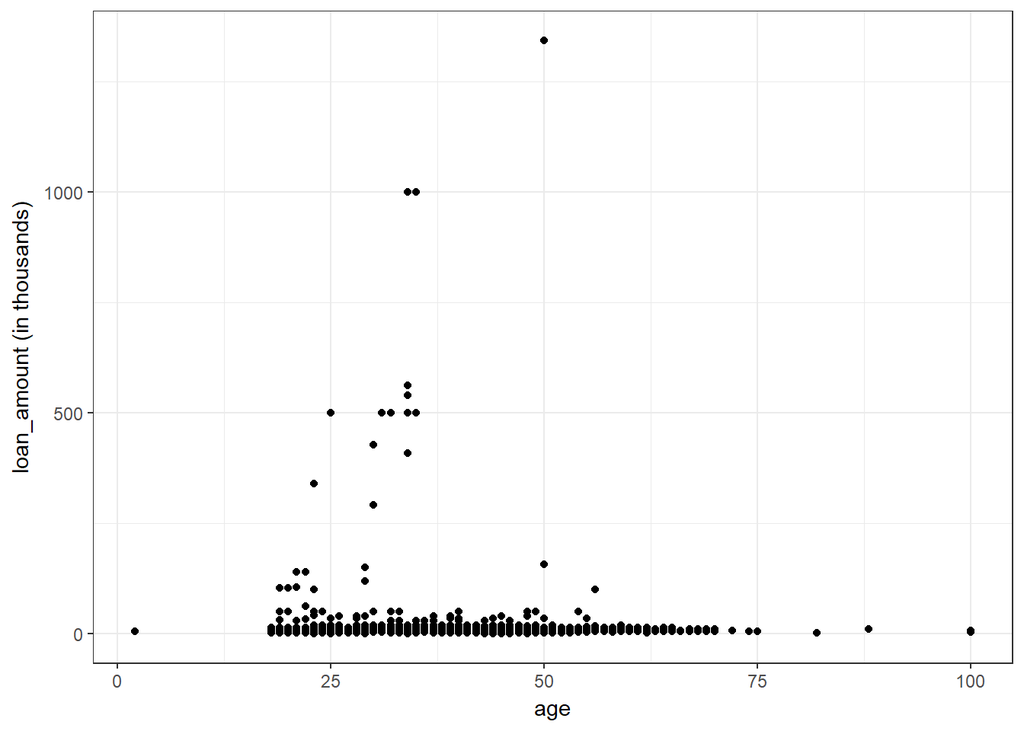

```r
ggplot(proc_data, aes(x = age, y = loan_amount/1000)) + geom_point() + ylab('loan_amount (in thousands)')
```

As we can see there are still outliers in data as most of the loan_amount is less than 20 thousands, specially there are values where age is near to zero. We have to remove these cases as age eligibilty for applying loan is 18 years.

```r
proc_data <- proc_data[!(proc_data$age < 18),]
```

We will leave other high values and see if it make sense during the modeling process

### Sex

As there are few high values in loan_amount we can use log loan_aamount

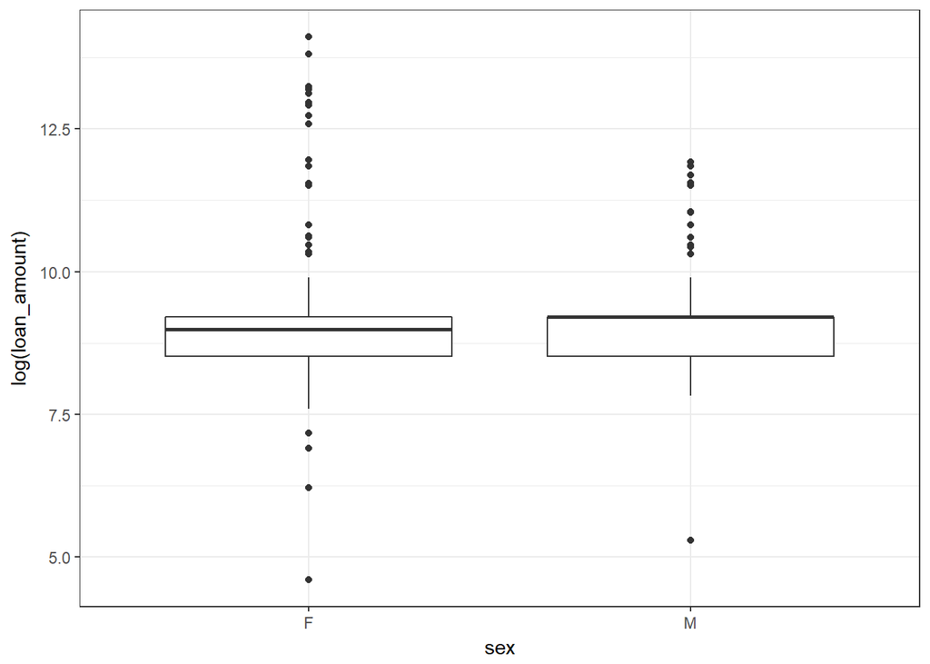

```r
log_loan_amount <- log(proc_data$loan_amount)
ggplot(proc_data, aes(x = sex, y = log_loan_amount)) + geom_boxplot() +
 ylab('log(loan_amount)')
```

loan_amount median is almost same for both genders except that females has more high value laon applied than males

### Social Class, Primary Business, Secondary Business

For Secondary business we know that it has so many none values reported. Let’s check it again

```r
sec_business_stat = proc_data %>% group_by(secondary_business) %>% summarise(count = n(), mean_laon_amt = mean(loan_amount), sd_loan_amt = sd(loan_amount)) %>% arrange(count, desc(count))
knitr::kable(sec_business_stat, digits = 2, align = 'c', caption = 'Loan Amount Stats for Secondary Business')
```

Loan Amount Stats for Secondary Business

| secondary_business | count | mean_laon_amt | sd_loan_amt |
| --- | --- | --- | --- |
| livestock rearing | 179 | 6256.98 | 2061.12 |
| agriculture | 2105 | 8677.91 | 31331.35 |
| daily wage labourer | 2545 | 7191.55 | 10069.64 |
| others | 2564 | 8349.96 | 3547.40 |
| unknown | 5239 | 5325.16 | 1990.62 |
| none | 27366 | 9117.02 | 13448.70 |

We will ignore this during the modeling.

### Annual Income and Monthly Expenses

These columns are inter related, as we understand that if we have more income more expense can be expected. It will be interesting to understand thier relationship with loan_amount.

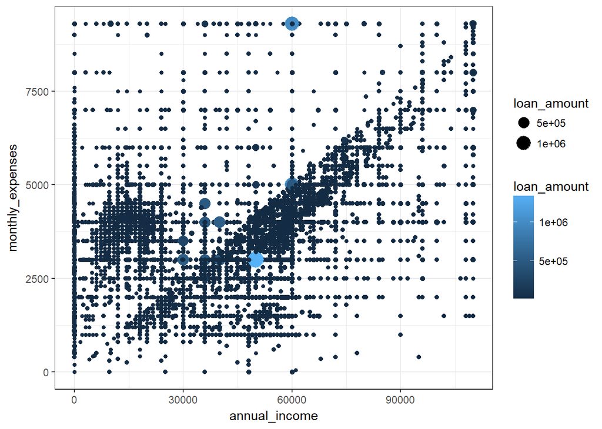

```r
ggplot(proc_data, aes(x = annual_income, y = monthly_expenses, color = loan_amount)) + geom_point(aes(size = loan_amount))
```

Let’s remove higher loan amount (more than 20k) to see whether we find any pattern

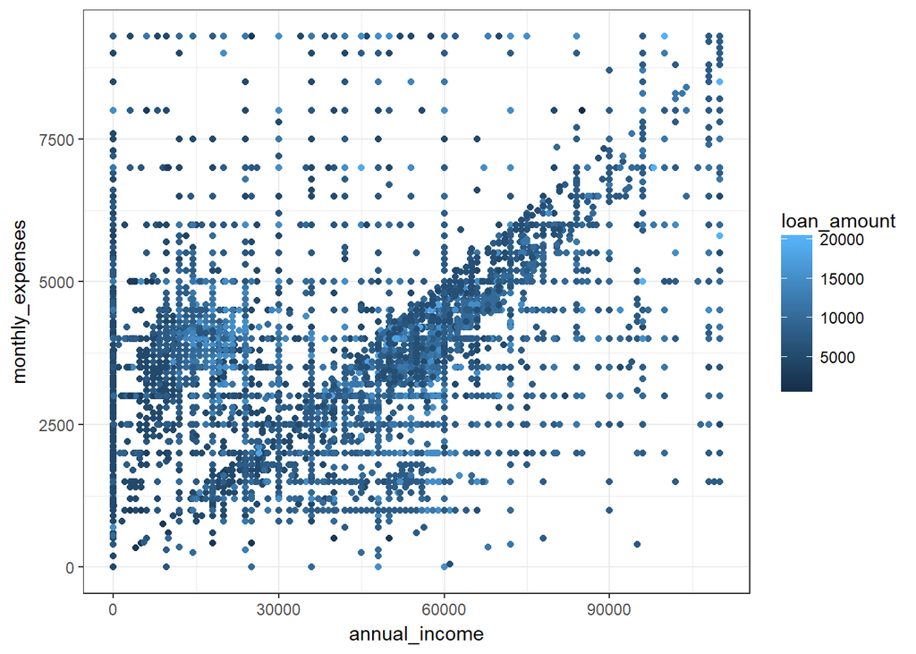

```r
plot_data <- proc_data[proc_data$loan_amount <= 20000, ]
ggplot(plot_data, aes(x = annual_income, y = monthly_expenses, color = loan_amount)) + geom_point()
```

```r
cor_mat <- cor(proc_data[, c('annual_income', 'monthly_expenses', 'loan_amount')])
knitr::kable(cor_mat, digits = 2, align = 'c', caption = 'Correlation Matrix')
```

Correlation Matrix

[output not shown]

## Data Modeling

Choose the variables which we want to include in the model

```r
keep_cols = c('age', 'sex', 'annual_income', 'monthly_expenses', 'old_dependents', 'young_dependents', 'home_ownership', 'type_of_house', 'occupants_count', 'house_area', 'sanitary_availability', 'water_availabity', 'loan_purpose', 'loan_tenure', 'loan_installments', 'loan_amount')
model_data <- proc_data[, keep_cols]
```

Let’s derive few more variables for modeling, we will also make all the charcter columns factor and dummy for creating models

```r
model_data$monthly_liability = model_data$annual_income/12 - model_data$monthly_expenses
model_data$dependents <- model_data$old_dependents + model_data$young_dependents
model_data$log_loan_amt <- log(model_data$loan_amount)
model_data$loan_amount <- NULL
model_data_factor <- model_data %>% mutate_if(is.character, as.factor)
model_data_dummy <- dummy.data.frame(model_data, sep = '_')
```

Let’s partition model_data versions in train and test sets

```r
train_index <- sample(nrow(model_data), size = 30000)
model_data_factor_train <- model_data_factor[train_index, ]
model_data_factor_test <- model_data_factor[-train_index, ]
model_data_dummy_train <- model_data_dummy[train_index, ]
model_data_dummy_test <- model_data_dummy[-train_index, ]
predictors_factor <- names(model_data_factor)[names(model_data_factor) !=  'log_loan_amt']
predictors_dummy <- names(model_data_dummy)[names(model_data_dummy) !=  'log_loan_amt']
```

Run the baseline model for both the datasets, we are going to use GBM method in caret to model as there are correlated variables in data and a tree based ensemble method can be a good baseline model

```r
myControl <- trainControl(method='cv', number=3, returnResamp='none', verboseIter = F)
base_model_factor <- train(model_data_factor_train[,predictors_factor], model_data_factor_train[,'log_loan_amt'], method='gbm', trControl=myControl)
base_model_dummy <- train(model_data_dummy_train[,predictors_dummy], model_data_dummy_train[,'log_loan_amt'], method='gbm', trControl=myControl)
```

Let’s check accuracy of both the models on test data

```r
pred_fac_out <- predict(base_model_factor, model_data_factor_test[, predictors_factor])
pred_dum_out <- predict(base_model_dummy, model_data_dummy_test[, predictors_dummy])
cat(RMSE(pred_fac_out, model_data_factor_test$log_loan_amt))
```

```
## 0.2830856
```

```r
cat(RMSE(pred_dum_out, model_data_dummy_test$log_loan_amt))
```

```
## 0.283821
```

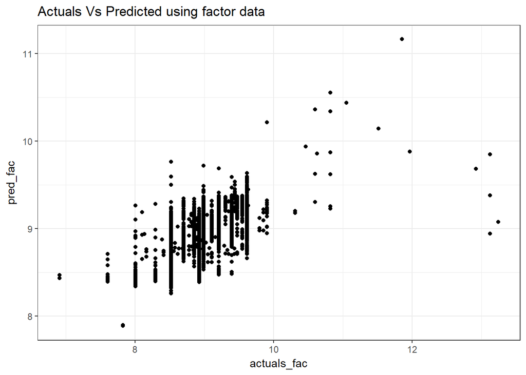

```r
plot_data <- data.frame(actuals_fac = model_data_factor_test$log_loan_amt,
                        pred_fac = pred_fac_out, actuals_dum = model_data_dummy_test$log_loan_amt, pred_dum = pred_dum_out)
ggplot(plot_data, aes(x = actuals_fac, y = pred_fac)) + geom_point() + ggtitle('Actuals Vs Predicted using factor data')
```

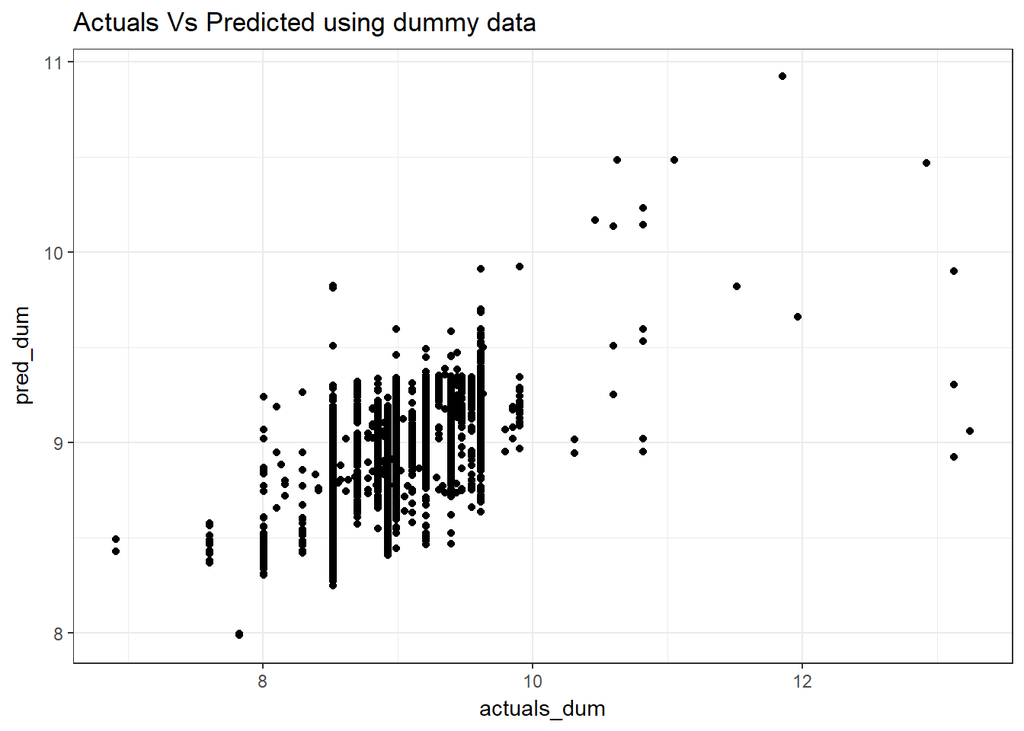

```r
ggplot(plot_data, aes(x = actuals_dum, y = pred_dum)) + geom_point() + ggtitle('Actuals Vs Predicted using dummy data')
```

### Variable Importance

```r
sum_fac <- summary(base_model_factor)
```

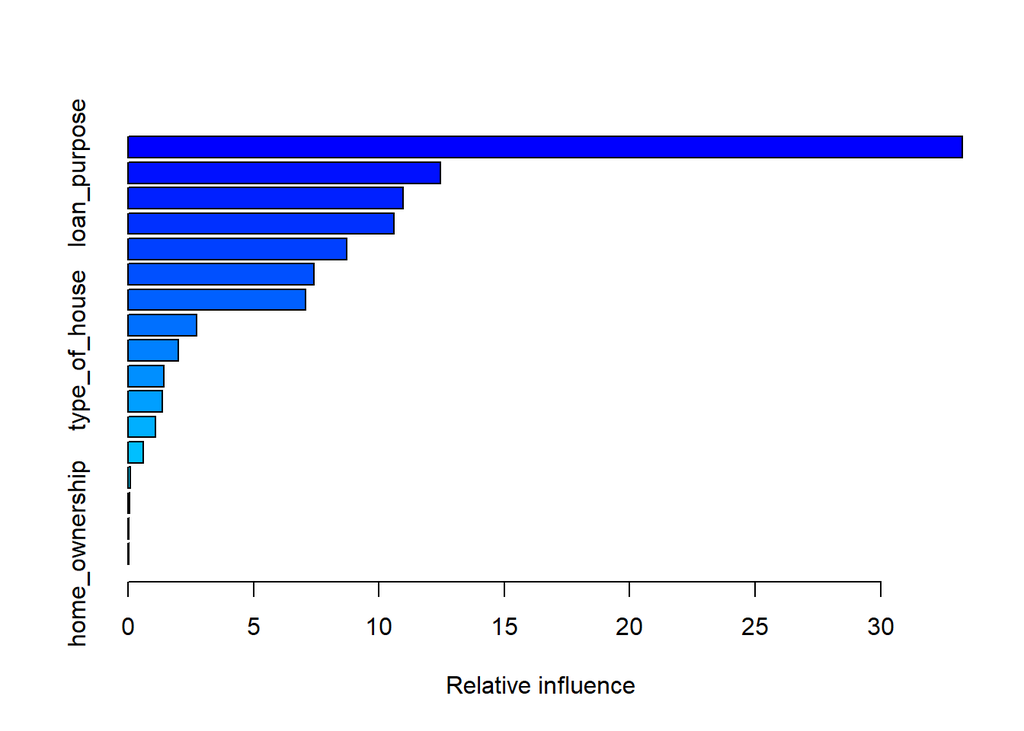

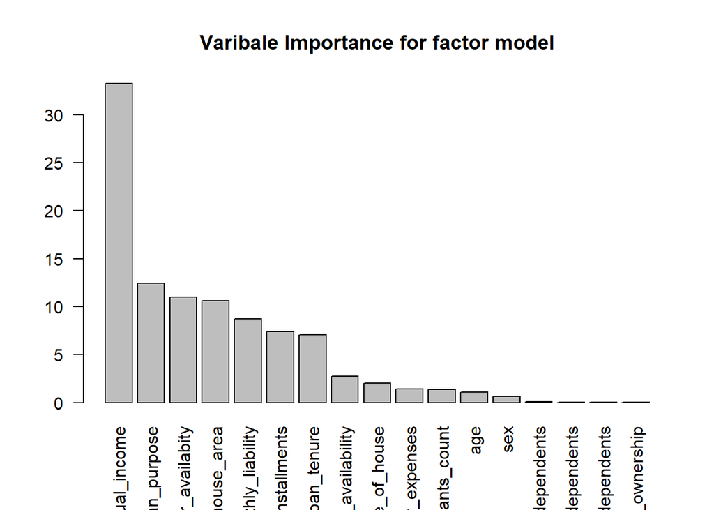

```r
barplot(height = sum_fac$rel.inf, names.arg = sum_fac$var, main = 'Varibale Importance for factor model', las = 2)
```

```r
sum_dum <- summary(base_model_dummy)
```

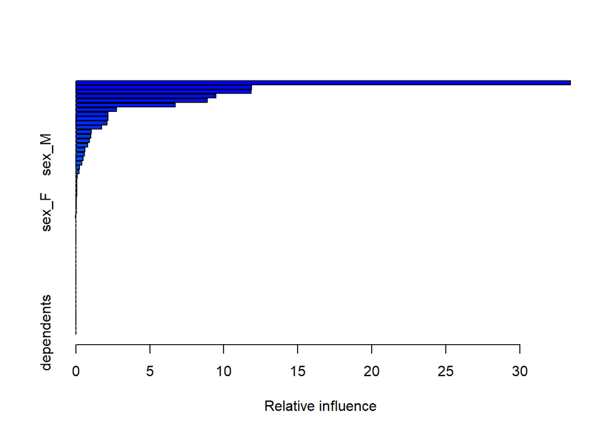

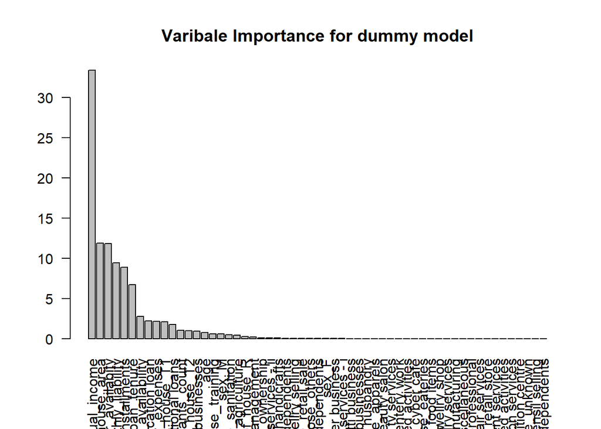

```r
barplot(height = sum_dum$rel.inf, names.arg = sum_dum$var, main = 'Varibale Importance for dummy model', las = 2)
```